# Exercise 06 – Large-Area Wall-to-Wall AGB Mapping with LAScatalog (RF) – START FROM NORMALIZED

Cesar Alvites - Forest Biometrics, Remote Sensing and AI Lab (SilvaLab). School of Forest, Fisheries and Geomatics Science, University of Florida, PO Box 110410 Gainesville, FL, USA 32611

2026-02-09

# 1 Objective

This exercise extends the plot-based wall-to-wall aboveground biomass (AGB) mapping workflow from Exercise 04 to **large areas containing many LiDAR tiles** . Unlike Exercise 04, this workflow **starts from already normalised tiles**, meaning **Z is height above ground** (m). Therefore, terrain modelling steps (e.g., CSF ground classification, DTM generation, and height normalisation) are **not repeated** here. The focus is on scalable metric extraction, Random Forest modelling, and wall-to-wall prediction.

# 2 Methodology

The modelling logic is consistent with Exercise 04:

1. **Read normalised LiDAR tiles** as a `LAScatalog` to enable memory-safe, chunk-based processing.
2. **Read field plots** with measured AGB and harmonise CRS with the LiDAR catalog.
3. **Clip plot-level point clouds** from the catalog (write one LAZ per plot) for consistent plot metrics.
4. **Compute plot-level LiDAR metrics** using the **same `f_metrics()` function** used for wall-to-wall mapping (training–prediction consistency).
5. **Train a Random Forest (ranger)** model and evaluate performance with an independent test set.
6. **Compute wall-to-wall metric tiles** with `catalog_apply()` and predict AGB per tile.
7. **Mosaic predicted AGB tiles** into a single GeoTIFF and export deliverables.

# 3 Input data

1. Normalised ALS tiles (.laz; Z already normalised to height above ground)
2. Plots (.gpkg / .shp / .geojson) containing plot ID and AGB

# 4 Expected output

1. Random Forest model (.rds)
2. Training table (.csv)
3. Accuracy table (.csv)
4. Wall-to-wall metric tiles (GeoTIFF)
5. AGB prediction tiles (GeoTIFF)
6. Final AGB mosaic (GeoTIFF) + map figure (.png)

# 5 R packages

- **lidR**: ALS/LiDAR processing, `LAScatalog`, chunk processing, and metric extraction
- **terra**: raster processing, prediction, mosaicking, and export
- **sf**: vector data I/O and CRS transformations
- **dplyr**: data wrangling for training tables
- **ranger**: fast Random Forest implementation
- **future**: parallel execution (multisession) for scalable chunk processing
- **tcltk**: interactive folder selection (tile folder)
- **ggplot2**: map figure export

# 6 Hands-on Steps

## 6.1 Loading R packages

```r
packages <- c("lidR","terra","sf","dplyr","ranger","future","tcltk","ggplot2")
missing_pkgs <- packages[!packages %in% installed.packages()[, "Package"]]
if (length(missing_pkgs) > 0) install.packages(missing_pkgs, dependencies = TRUE)
suppressMessages(lapply(packages, library, character.only = TRUE))

options(lidR.progress = FALSE)

terra_temp <- file.path(tempdir(), "terra_tmp")
dir.create(terra_temp, recursive = TRUE, showWarnings = FALSE)
terra::terraOptions(tempdir = terra_temp)
```

## 6.2 User inputs (interactive)

Select (1) the folder containing **normalised** LAZ tiles, and (2) the plots file containing AGB.

```r
cat("Select the folder containing NORMALIZED LAZ tiles (Z already normalized)...\n")
```

```
## Select the folder containing NORMALIZED LAZ tiles (Z already normalized)...
```

```r
norm_dir <- tcltk::tk_choose.dir(caption = "Select NORMALIZED LAZ tile folder")
if (is.na(norm_dir) || norm_dir == "") stop("No normalized folder selected.")

cat("Select the plot file (GeoPackage / Shapefile / GeoJSON) containing AGB...\n")
```

```
## Select the plot file (GeoPackage / Shapefile / GeoJSON) containing AGB...
```

```r
plots_path <- file.choose()
if (is.na(plots_path) || plots_path == "") stop("No plots file selected.")
```

## 6.3 User parameters

These parameters control plot geometry handling, CRS metadata assignment, mapping resolution, chunk buffering, height filtering, parallelisation, and Random Forest settings.

```r
id_col  <- "plotID_best"
agb_col <- "AGB"

plots_are_points <- FALSE
plot_radius_m <- 20

# If CRS missing in tiles, assign it here (metadata only)
epsg_target <- 32617

# Metrics resolution for mapping
metrics_res   <- 40
metrics_start <- c(0, 0)

# Catalog chunking
chunk_size   <- 0
chunk_buffer <- 30

# Height filtering (normalized heights)
max_norm_height <- 80

# Parallel
use_parallel <- TRUE
n_workers   <- 4
omp_threads <- 1   # IMPORTANT with future

# RF
rf_num_trees <- 600
train_frac   <- 0.70

# Metrics to EXCLUDE (problematic bands)
metrics_to_exclude <- c("TotalReturns")
```

## 6.4 Output folder structure (single root folder)

All products are saved under a single root folder:

```r
out_dir <- file.path(dirname(norm_dir), "ForestSAT2026_05_Exercise")

dir.create(out_dir,  showWarnings = FALSE, recursive = TRUE)

dir_clips   <- file.path(out_dir, "01_plot_clips_norm")
dir_metrics <- file.path(out_dir, "02_metrics_tiles")
dir_pred    <- file.path(out_dir, "03_agb_tiles_from_metrics")

dir.create(dir_clips,   showWarnings = FALSE, recursive = TRUE)
dir.create(dir_metrics, showWarnings = FALSE, recursive = TRUE)
dir.create(dir_pred,    showWarnings = FALSE, recursive = TRUE)

model_rds   <- file.path(out_dir, "final_model_rf.rds")
train_csv   <- file.path(out_dir, "training_table.csv")
metrics_csv <- file.path(out_dir, "rf_accuracy_metrics.csv")
```

## 6.5 Parallel plan (chunk-based)

Parallelism is handled by **future** at the chunk/tile level.  
To avoid nested parallelism, keep `lidR` threads to **1** (`omp_threads <- 1`).

```r
if (use_parallel) {
  future::plan(future::multisession, workers = as.integer(n_workers))
} else {
  future::plan(future::sequential)
}
lidR::set_lidr_threads(omp_threads)
```

## 6.6 Step A: Read LAScatalog from normalised tiles

A `LAScatalog` enables scalable reading and processing of many tiles. Filters are applied to remove withheld/overlap points and enforce a valid height range.

```r
ctg_norm <- lidR::readLAScatalog(norm_dir)

if (is.na(sf::st_crs(ctg_norm))) {
  message("Catalog CRS is missing. Assigning EPSG:", epsg_target)
  sf::st_crs(ctg_norm) <- sf::st_crs(epsg_target)
}

if (!lidR::is.indexed(ctg_norm)) {
  message("No .lax index found. Creating .lax files (recommended)...")
  tryCatch(lidR:::catalog_laxindex(ctg_norm),
           error = function(e) message("Could not create .lax indexes. Continue anyway."))
}

lidR::opt_select(ctg_norm) <- "xyzicrn"
lidR::opt_filter(ctg_norm) <- paste(
  "-drop_withheld -drop_overlap",
  sprintf("-drop_z_below %g", 0),
  sprintf("-drop_z_above %g", max_norm_height)
)
lidR::opt_chunk_size(ctg_norm)   <- chunk_size
lidR::opt_chunk_buffer(ctg_norm) <- chunk_buffer
lidR::opt_wall_to_wall(ctg_norm) <- TRUE
```

## 6.7 Step B: Read plots and harmonise CRS

Plots are read and transformed to match the catalog CRS. If plots are points, they can be buffered into circular plots.

```r
plots <- sf::st_read(plots_path, quiet = TRUE)
if (!all(c(id_col, agb_col) %in% names(plots))) {
  stop("Plots file must contain columns: ", id_col, " and ", agb_col)
}

plots <- sf::st_transform(plots, sf::st_crs(ctg_norm))

if (plots_are_points) {
  plots <- sf::st_buffer(plots, dist = plot_radius_m)
}

plots <- plots %>% dplyr::select(dplyr::all_of(c(id_col, agb_col)), geometry)
```

## 6.8 Step C: Clip normalised point clouds by plots (writes one LAZ per plot)

Each plot polygon is used to clip the catalog and write plot-level LAZ/ LAS files. These plot clips are later used to compute plot-level metrics consistently.

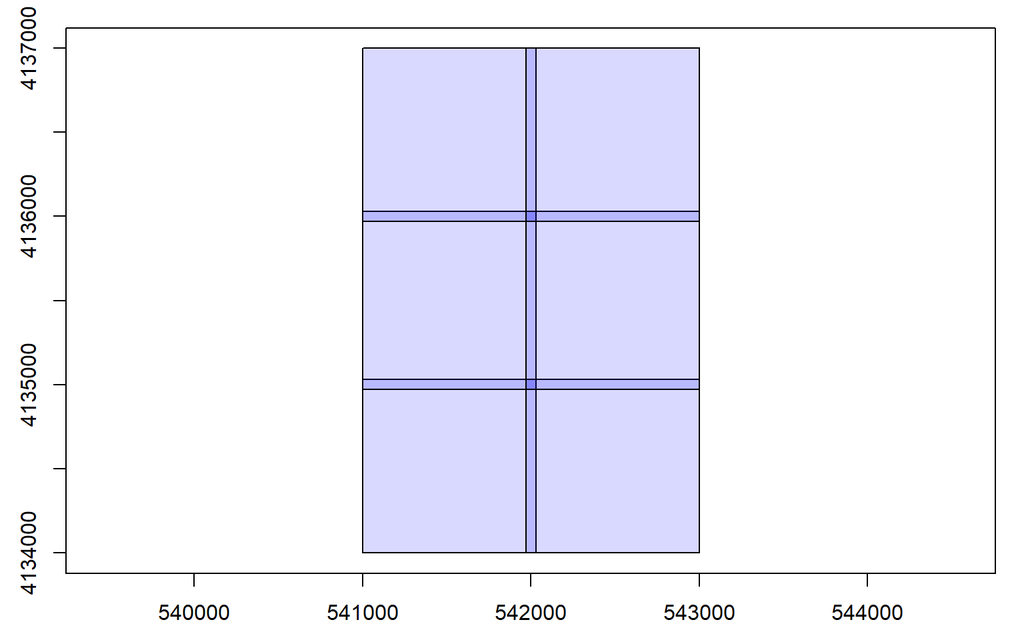

```
## Chunk 1 of 10 (10%): state ✓
##                                                                                 Chunk 2 of 10 (20%): state ✓
##                                                                                 Chunk 3 of 10 (30%): state ✓
##                                                                                 Chunk 4 of 10 (40%): state ✓
##                                                                                 Chunk 5 of 10 (50%): state ✓
##                                                                                 Chunk 7 of 10 (60%): state ✓
##                                                                                 Chunk 6 of 10 (70%): state ✓
##                                                                                 Chunk 8 of 10 (80%): state ✓
##                                                                                 Chunk 9 of 10 (90%): state ✓
##                                                                                 Chunk 10 of 10 (100%): state ✓
##
```

```
## class       : LAScatalog (v1.3 format 3)
## extent      : 541864, 542652.3, 4134595, 4136540 (xmin, xmax, ymin, ymax)
## coord. ref. : WGS 84 / UTM zone 17N
## area        : 15997.72 m²
## points      : 654.5 thousand points
## type        : airborne
## density     : 40.9 points/m²
## density     : 14.5 pulses/m²
## num. files  : 10
```

```r
plots_clip <- plots %>% dplyr::rename(ID = !!id_col)

message("Clipping normalized point clouds by plot geometry (writing files)...")

ctg_clip <- ctg_norm
lidR::opt_output_files(ctg_clip) <- file.path(dir_clips, "plot_{ID}")
lidR::opt_laz_compression(ctg_clip) <- TRUE

lidR::clip_roi(ctg_clip, plots_clip)
```

```r
clip_files <- list.files(dir_clips, pattern = "\\.(las|laz)$", full.names = TRUE, ignore.case = TRUE)
if (length(clip_files) == 0) stop("No plot clips were written. Check CRS and plot overlap with tiles.")
```

## 6.9 Step D: Build training table using the same `f_metrics()` used for mapping

This step ensures training–mapping consistency by computing plot-level predictors with the same metric function used wall-to-wall.

```r
plot_metrics_one <- function(las, min_pts = 30) {
  if (is.null(las) || lidR::is.empty(las)) return(NULL)
  d <- las@data
  d <- d[is.finite(d$Z) & d$Z >= 0 & d$Z <= max_norm_height, , drop = FALSE]
  if (nrow(d) < min_pts) return(NULL)

  intensity <- if ("Intensity" %in% names(d)) d$Intensity else rep(NA_real_, nrow(d))
  m <- f_metrics(d$X, d$Y, d$Z, intensity)
  as.data.frame(as.list(m))
}

message("Computing plot-level metrics from plot clips...")

metrics_list <- lapply(clip_files, function(f) {
  las <- lidR::readLAS(f)
  mdf <- plot_metrics_one(las, min_pts = 30)
  if (is.null(mdf)) return(NULL)
  pid <- sub("^plot_", "", tools::file_path_sans_ext(basename(f)))
  mdf$plot_id <- as.character(pid)
  mdf
})
```

```r
metrics_df <- dplyr::bind_rows(metrics_list)
if (nrow(metrics_df) == 0) stop("All plot clips were empty or produced no metrics.")

plots_tbl <- sf::st_drop_geometry(plots) %>%
  dplyr::transmute(
    plot_id = as.character(.data[[id_col]]),
    y       = as.numeric(.data[[agb_col]])
  )

train_df <- plots_tbl %>%
  dplyr::inner_join(metrics_df, by = "plot_id") %>%
  dplyr::filter(is.finite(y)) %>%
  dplyr::select(where(~ !all(is.na(.))))

write.csv(train_df, train_csv, row.names = FALSE)
message("Training table saved: ", train_csv)
```

## 6.10 Step E: Train Random Forest (ranger) + evaluation + save model

The model is trained with a 70/30 train–test split and evaluated with standard regression accuracy metrics (reported for train and test). The fitted RF is saved as an `.rds` file.

```r
pred_cols <- setdiff(names(train_df), c("plot_id", "y"))
is_num <- sapply(train_df[, pred_cols, drop = FALSE], is.numeric)
pred_cols <- pred_cols[is_num]

# Exclude problematic metrics from modeling
pred_cols <- setdiff(pred_cols, metrics_to_exclude)

dat_use <- train_df[, c("plot_id", "y", pred_cols)]
dat_use <- dat_use[stats::complete.cases(dat_use[, c("y", pred_cols)]), , drop = FALSE]

n <- nrow(dat_use)
if (n < 4) stop("Not enough plots for training. Need at least 4 complete cases.")

idx <- sample(seq_len(n))
n_train  <- max(2, floor(train_frac * n))
train_id <- idx[1:n_train]
test_id  <- setdiff(idx, train_id)

train <- dat_use[train_id, , drop = FALSE]
test  <- dat_use[test_id,  , drop = FALSE]

target   <- "y"
features <- pred_cols

rf_fit <- ranger(
  dependent.variable.name = target,
  data       = train[, c(target, features)],
  num.trees  = rf_num_trees,
  mtry       = max(1, floor(sqrt(length(features)))),
  importance = "impurity",
  seed       = 42
)

pred_train <- predict(rf_fit, data = train[, features, drop = FALSE])$predictions
pred_test  <- predict(rf_fit, data = test[,  features, drop = FALSE])$predictions

metrics_out <- dplyr::bind_rows(
  extract_metrics(train$y, pred_train, model_name = "RF_ranger", part_name = "train") |>
    dplyr::mutate(n = nrow(train), .before = 1),
  extract_metrics(test$y,  pred_test,  model_name = "RF_ranger", part_name = "test")  |>
    dplyr::mutate(n = nrow(test),  .before = 1)
)

write.csv(metrics_out, metrics_csv, row.names = FALSE)
saveRDS(rf_fit, model_rds)

message("RF model saved: ", model_rds)
message("Accuracy metrics saved: ", metrics_csv)

# Safety: ensure excluded metrics are not in 'features'
features <- setdiff(rf_fit$independent.variable.names, metrics_to_exclude)
```

## 6.11 Accuracy assessment

Accuracy is reported for both training and independent test data. In reporting, emphasise the **test** performance (RMSE, RMSE%, MAE, bias/MD, R²) as the indicator of model generalisation.

```r
print(metrics_out)
```

```
##   n     model  part        r2     rmse    rmseR       bias     biasR      mae
## 1 7 RF_ranger train 0.9034344 15.60472 14.36903  0.1845695  0.169954 14.35551
## 2 3 RF_ranger  test 0.3100952 27.67790 23.22882 -7.2091154 -6.050287 23.34014
##       maeR
## 1 13.21873
## 2 19.58833
```

## 6.12 Step F1: Compute wall-to-wall METRICS tiles with `catalog_apply()`

Wall-to-wall predictor tiles are generated by computing `pixel_metrics()` per catalog chunk. The chunk buffer reduces edge effects; outputs are cropped back to the core chunk extent to remove overlap.

```r
metrics_chunk <- function(chunk, res, start, max_h) {

  las <- lidR::readLAS(chunk)
  if (is.null(las) || lidR::is.empty(las)) return(NULL)

  las <- lidR::filter_poi(las, Z >= 0 & Z <= max_h)
  if (lidR::is.empty(las)) return(NULL)

  m <- lidR::pixel_metrics(
    las   = las,
    func  = ~f_metrics(X, Y, Z, Intensity),
    res   = res,
    start = start,
    pkg   = "terra",
    geom  = "bbox"
  )
  if (is.null(m)) return(NULL)

  # Crop to chunk extent (remove buffer overlap)
  m <- terra::crop(m, terra::ext(chunk))
  m
}

message("Step F1: computing METRICS tiles with catalog_apply()...")

lidR::opt_output_files(ctg_norm) <- file.path(dir_metrics, "METRICS_{XLEFT}_{YBOTTOM}")

options_engine_metrics <- list(
  need_output_file = TRUE,
  need_buffer      = TRUE,
  automerge        = FALSE,
  overwrite        = TRUE
)

metrics_files <- lidR::catalog_apply(
  ctg_norm,
  metrics_chunk,
  res      = metrics_res,
  start    = metrics_start,
  max_h    = max_norm_height,
  .options = options_engine_metrics
)
```

[output not shown]

[output not shown]

[output not shown]

[output not shown]

[output not shown]

[output not shown]

[output not shown]

```r
metrics_files <- unlist(metrics_files, use.names = FALSE)
metrics_files <- metrics_files[file.exists(metrics_files)]
if (length(metrics_files) == 0) stop("No METRICS tiles were written.")

message("METRICS tiles written to: ", dir_metrics)
```

## 6.13 Step F2: Predict AGB tiles from METRICS tiles using `terra::predict()`

Each metrics tile is read, aligned to the model predictors (drop excluded metrics; pad missing predictors with NA), and predicted using the trained RF model. Outputs are saved as AGB GeoTIFF tiles.

```r
message("Step F2: predicting AGB tiles from METRICS tiles using terra::predict()...")

agb_files <- character(0)
#remind this information  #urgent
target = "y"
features= pred_cols

for (f in metrics_files) {

  metrics_r <- terra::rast(f)

  # Drop excluded metric bands if present (e.g., TotalReturns)
  drop_now <- intersect(metrics_to_exclude, names(metrics_r))
  if (length(drop_now) > 0) {
    metrics_r <- metrics_r[[setdiff(names(metrics_r), drop_now)]]
  }

  # Pad missing predictors (if needed)
  missing <- setdiff(features, names(metrics_r))
  if (length(missing) > 0) {
    na_layer <- metrics_r[[1]]
    na_layer[] <- NA_real_
    for (m in missing) {
      metrics_r <- c(metrics_r, na_layer)
      names(metrics_r)[terra::nlyr(metrics_r)] <- m
    }
  }

  x_r <- metrics_r[[features]]
  names(x_r) <- features

  out_path <- file.path(dir_pred, paste0("AGB_", tools::file_path_sans_ext(basename(f)), ".tif"))

  terra::predict(
    x_r,
    model     = rf_fit,
    na.rm     = TRUE,
    cores     = 1,
    filename  = out_path,
    overwrite = TRUE
  )

  agb_files <- c(agb_files, out_path)
}

agb_files <- agb_files[file.exists(agb_files)]
if (length(agb_files) == 0) stop("No AGB tiles were written from metrics.")

message("AGB tiles written to: ", dir_pred)
```

## 6.14 Step G: Mosaic AGB tiles + plot + export

All predicted tiles are mosaicked into a single AGB map. The mosaic is exported as GeoTIFF and visualised as a PNG figure.

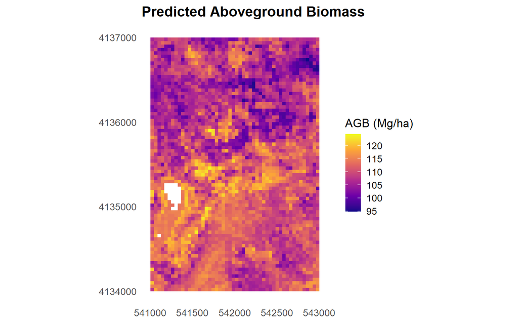

```r
agb_coll   <- sprc(agb_files)
agb_mosaic <- mosaic(agb_coll, fun = "mean")

# Save final mosaic GeoTIFF (single root folder)
out_mosaic_tif <- file.path(out_dir, "AGB_40m_mosaic.tif")
writeRaster(agb_mosaic, out_mosaic_tif, overwrite = TRUE)
message("Final AGB mosaic saved: ", out_mosaic_tif)

# ggplot map
df_pred <- as.data.frame(agb_mosaic, xy = TRUE, na.rm = TRUE)
names(df_pred) <- c("x", "y", "AGB")

p_agb <- ggplot(df_pred) +
  geom_raster(aes(x = x, y = y, fill = AGB)) +
  scale_fill_viridis_c(option = "C", name = "AGB (Mg/ha)") +
  coord_equal() +
  labs(title = "Predicted Aboveground Biomass", x = NULL, y = NULL) +
  theme_minimal(base_size = 13) +
  theme(
    panel.grid = element_blank(),
    plot.title = element_text(face = "bold"),
    legend.position = "right"
  )

print(p_agb)
```

```r
# Save ggplot figure (single root folder)
out_png <- file.path(out_dir, "AGB_40m_mosaic.png")
ggsave(out_png, plot = p_agb, width = 8, height = 6, dpi = 400)
message("AGB mosaic figure saved: ", out_png)

# Save tile list (helpful for QA)
writeLines(agb_files, con = file.path(out_dir, "AGB_tile_list.txt"))

message("ALL outputs are under: ", out_dir)
```

# 7 Reference

- Roussel, J.-R., Auty, D., Coops, N. C., Tompalski, P., Goodbody, T. R. H., Meador, A. S., & Achim, A. (2020). lidR: An R package for analysis of Airborne Laser Scanning (ALS) data. *Remote Sensing of Environment, 251*, 112061.
- Hijmans, R. J., et al. (2022). *terra*: Spatial data analysis. CRAN.
- Wright, M. N., Wager, S., Probst, P., & Wright, M. M. N. (2019). *ranger*: A fast implementation of Random Forests. CRAN.

# 8 Key takeaways

1. **LAScatalog enables scalable processing for large AOIs.**  
   Chunk-based reading, buffering, and tile outputs allow wall-to-wall mapping across hundreds of files.
2. **Training–mapping consistency is essential.**  
   Using the same `f_metrics()` function for plot metrics and wall-to-wall metrics improves robustness and reduces predictor mismatch.
3. **Most mapping artefacts come from predictor rasters and edge handling.**  
   Buffers, cropping to chunk extent, and quality checks of metric/prediction tiles are critical before interpretation.